# Elsevier 2022 SDG mapping

)

)

)

)

OR

(

(

(

(

TITLE-ABS("teenager*") AND TITLE-ABS("contraceptive* use*")

)

OR

(

AUTHKEY("teenager*") AND AUTHKEY("contraceptive* use*")

)

OR

(

TITLE-ABS("family planning") AND (TITLE-ABS("prevention") OR TITLE-ABS("education") OR TITLE-ABS("transmission"))

)

OR

(

AUTHKEY("family planning") AND (AUTHKEY("prevention") OR AUTHKEY("education") OR AUTHKEY("transmission"))

)

OR TITLE-ABS

(

"reproductive* right*"

)

OR AUTHKEY

(

"reproductive* right*"

)

OR TITLE-ABS

(

"STDs education"

)

OR AUTHKEY

(

"STDs education"

)

OR TITLE-ABS

(

"sex and relationship education"

)

OR AUTHKEY

(

"sex and relationship education"

)

OR

(

TITLE-ABS("violence") AND TITLE-ABS("reproductive health")

)

OR

(

AUTHKEY("violence") AND AUTHKEY("reproductive health")

)

OR TITLE-ABS

(

"Sexuality education"

)

OR AUTHKEY

(

"Sexuality education"

)

OR TITLE-ABS

(

"sexual education"

)

OR AUTHKEY

(

"sexual education"

)

OR

(

TITLE-ABS("abortion* right*") OR TITLE-ABS("rights to abortion") OR TITLE-ABS("right to abortion") OR (TITLE-ABS("women''s* right*") AND TITLE-ABS("abortion")) OR (TITLE-ABS("woman''s* right*") AND TITLE-ABS("abortion"))

)

OR

(

AUTHKEY("abortion* right*") OR AUTHKEY("rights to abortion") OR AUTHKEY("right to abortion") OR (AUTHKEY("women''s* right*") AND AUTHKEY("abortion")) OR (AUTHKEY("woman''s* right*") AND AUTHKEY("abortion"))

)

OR

(

(TITLE-ABS("transmission") OR TITLE-ABS("education") OR TITLE-ABS("prevention")) AND (TITLE-ABS("Sexually* transmitted* disease*") OR TITLE-ABS("STD") OR TITLE-ABS("STDs") OR TITLE-ABS("HIV"))

)

OR

(

(AUTHKEY("transmission") OR AUTHKEY("education") OR AUTHKEY("prevention")) AND (AUTHKEY("Sexually* transmitted* disease*") OR AUTHKEY("STD") OR AUTHKEY("STDs") OR AUTHKEY("HIV"))

)

OR

(

TITLE-ABS("condom use") OR TITLE-ABS("access to condoms")

)

OR

(

AUTHKEY("condom use") OR AUTHKEY("access to condoms")

)

OR

(

TITLE-ABS("hiv-infected pregnant women") OR TITLE-ABS("hivinfected pregnant women")

)

OR

(

AUTHKEY("hiv-infected pregnant women") OR AUTHKEY("hivinfected pregnant women")

)

OR

(

TITLE-ABS("reproductive health") AND (TITLE-ABS("education") OR TITLE-ABS("service*"))

)

OR

(

AUTHKEY("reproductive health") AND (AUTHKEY("education") OR AUTHKEY("service*"))

)

OR TITLE-ABS

(

"barriers to condom use"

)

OR AUTHKEY

(

"barriers to condom use"

)

OR TITLE-ABS

(

"female* circumcision*"

)

OR AUTHKEY

(

"female* circumcision*"

)

OR TITLE-ABS

(

"Right* to* contracept*"

)

OR AUTHKEY

(

"Right* to* contracept*"

)

OR

(

TITLE-ABS("Emergency contraception") AND (TITLE-ABS("risk* habit*") OR TITLE-ABS("risk* behavior*") OR TITLE-ABS("risk* behaviour*")) AND TITLE-ABS("education")

)

OR

(

AUTHKEY("Emergency contraception") AND (AUTHKEY("risk* habit*") OR AUTHKEY("risk* behavior*") OR AUTHKEY("risk* behaviour*")) AND AUTHKEY("education")

)

OR TITLE-ABS

(

"Rights* to* contracept*"

)

OR AUTHKEY

(

"Rights* to* contracept*"

)

OR

(

(TITLE-ABS("pre-exposure prophylaxis") AND (TITLE-ABS("STDs") OR TITLE-ABS("sexually* transmitted* disease*"))) OR (TITLE-ABS("preexposure prophylaxis") AND (TITLE-ABS("STDs") OR TITLE-ABS("sexually* transmitted* disease*")))

)

OR

(

(AUTHKEY("pre-exposure prophylaxis") AND (AUTHKEY("STDs") OR AUTHKEY("sexually* transmitted* disease*"))) OR (AUTHKEY("preexposure prophylaxis") AND (AUTHKEY("STDs") OR AUTHKEY("sexually* transmitted* disease*")))

)

OR TITLE-ABS

(

"sexual health"

)

OR AUTHKEY

(

"sexual health"

)

OR TITLE-ABS

(

"HIV education"

)

OR AUTHKEY

(

"HIV education"

)

OR

(

TITLE-ABS("reproductive* choice*") AND (TITLE-ABS("women") OR TITLE-ABS("woman") OR TITLE-ABS("girl*"))

)

OR

(

AUTHKEY("reproductive* choice*") AND (AUTHKEY("women") OR AUTHKEY("woman") OR AUTHKEY("girl*"))

)

OR TITLE-ABS

(

"healthy sexuality"

)

OR AUTHKEY

(

"healthy sexuality"

)

OR

(

TITLE-ABS("sexual* risk*") AND (TITLE-ABS("education") OR TITLE-ABS("prevention") OR TITLE-ABS("behav*"))

)

OR

(

AUTHKEY("sexual* risk*") AND (AUTHKEY("education") OR AUTHKEY("prevention") OR AUTHKEY("behav*"))

)

OR TITLE-ABS

(

"condom* availabilit*"

)

OR AUTHKEY

(

"condom* availabilit*"

)

OR

(

(TITLE-ABS("mother-to-child transmission") OR TITLE-ABS("mother-to-child transmissions")) OR (TITLE-ABS("mothertochild transmission") OR TITLE-ABS("mothertochild transmissions"))

)

OR

(

(AUTHKEY("mother-to-child transmission") OR AUTHKEY("mother-to-child transmissions")) OR (AUTHKEY("mothertochild transmission") OR AUTHKEY("mothertochild transmissions"))

)

OR

(

(TITLE-ABS("genital* cutting*") OR TITLE-ABS("genital* mutilation*")) AND (TITLE-ABS("female") OR TITLE-ABS("women") OR TITLE-ABS("woman") OR TITLE-ABS("girl*") OR TITLE-ABS("child*"))

)

OR

(

(AUTHKEY("genital* cutting*") OR AUTHKEY("genital* mutilation*")) AND (AUTHKEY("female") OR AUTHKEY("women") OR AUTHKEY("woman") OR AUTHKEY("girl*") OR AUTHKEY("child*"))

)

OR

(

TITLE-ABS("Contraceptive use ") AND (TITLE-ABS("information") OR TITLE-ABS("education*"))

)

OR

(

AUTHKEY("Contraceptive use ") AND (AUTHKEY("information") OR AUTHKEY("education*"))

)

OR

(

TITLE-ABS("Family planning") AND (TITLE-ABS("prevention") OR TITLE-ABS("preventing"))

)

OR

(

AUTHKEY("Family planning") AND (AUTHKEY("prevention") OR AUTHKEY("preventing"))

)

OR TITLE-ABS

(

"sexual and reproductive health"

)

OR AUTHKEY

(

"sexual and reproductive health"

)

OR TITLE-ABS

(

"sex education"

)

OR AUTHKEY

(

"sex education"

)

OR

(

((TITLE-ABS("own") OR TITLE-ABS("informed")) AND TITLE-ABS("decision")) AND (TITLE-ABS("sexual") OR TITLE-ABS("contracepti*") OR TITLE-ABS("reproducti*") OR TITLE-ABS("family planning") OR TITLE-ABS("parenting* plan*") OR TITLE-ABS("abortion"))

)

OR

(

((AUTHKEY("own") OR AUTHKEY("informed")) AND AUTHKEY("decision")) AND (AUTHKEY("sexual") OR AUTHKEY("contracepti*") OR AUTHKEY("reproducti*") OR AUTHKEY("family planning") OR AUTHKEY("parenting* plan*") OR AUTHKEY("abortion"))

)

OR TITLE-ABS

(

"arranged* marriage*"

)

OR AUTHKEY

(

"arranged* marriage*"

)

OR

(

(TITLE-ABS("Sexual functioning") OR TITLE-ABS("sexuality")) AND TITLE-ABS("postpartum")

)

OR

(

(AUTHKEY("Sexual functioning") OR AUTHKEY("sexuality")) AND AUTHKEY("postpartum")

)

OR

(

TITLE-ABS("reproductive* decision*") AND (TITLE-ABS("women") OR TITLE-ABS("woman") OR TITLE-ABS("girl*"))

)

OR

(

AUTHKEY("reproductive* decision*") AND (AUTHKEY("women") OR AUTHKEY("woman") OR AUTHKEY("girl*"))

)

OR TITLE-ABS

(

"early sexual initiation"

)

OR AUTHKEY

(

"early sexual initiation"

)

OR

(

TITLE-ABS("risk* behavior*") AND (TITLE-ABS("STDs") OR TITLE-ABS("sexually* transmitted* disease*"))

)

OR

(

AUTHKEY("risk* behavior*") AND (AUTHKEY("STDs") OR AUTHKEY("sexually* transmitted* disease*"))

)

OR TITLE-ABS

(

"contracept* educat*"

)

OR AUTHKEY

(

"contracept* educat*"

)

OR

(

TITLE-ABS("Family planning") AND TITLE-ABS("multiparous women")

)

OR

(

AUTHKEY("Family planning") AND AUTHKEY("multiparous women")

)

OR TITLE-ABS

(

"Teaching sexuality"

)

OR AUTHKEY

(

"Teaching sexuality"

)

OR

(

(TITLE-ABS("Hypersexual*") OR TITLE-ABS("hyper*-sexual*")) OR (TITLE-ABS("Hypersexual*") OR TITLE-ABS("hypersexual*"))

)

OR

(

(AUTHKEY("Hypersexual*") OR AUTHKEY("hyper*-sexual*")) OR (AUTHKEY("Hypersexual*") OR AUTHKEY("hypersexual*"))

)

OR

(

TITLE-ABS("Menstrual hygiene") AND TITLE-ABS("reproductive health") AND TITLE-ABS("programmes")

)

OR

(

AUTHKEY("Menstrual hygiene") AND AUTHKEY("reproductive health") AND AUTHKEY("programmes")

)

OR TITLE-ABS

(

"contraceptive* decision*"

)

OR AUTHKEY

(

"contraceptive* decision*"

)

OR

(

TITLE-ABS("pregnant women") AND (TITLE-ABS("STDs") OR TITLE-ABS("sexually* transmitted* disease*"))

)

OR

(

AUTHKEY("pregnant women") AND (AUTHKEY("STDs") OR AUTHKEY("sexually* transmitted* disease*"))

)

OR

(

(TITLE-ABS("sexual rights") OR TITLE-ABS("reproductive rights") OR TITLE-ABS("divorce rights")) AND (TITLE-ABS("female") OR TITLE-ABS("women") OR TITLE-ABS("woman") OR TITLE-ABS("girl*"))

)

OR

(

(AUTHKEY("sexual rights") OR AUTHKEY("reproductive rights") OR AUTHKEY("divorce rights")) AND (AUTHKEY("female") OR AUTHKEY("women") OR AUTHKEY("woman") OR AUTHKEY("girl*"))

)

OR

(

(TITLE-ABS("AIDS education") OR TITLE-ABS("AIDS-prevention") OR TITLE-ABS("HIV education")) OR (TITLE-ABS("AIDS education") OR TITLE-ABS("AIDSprevention") OR TITLE-ABS("HIV education"))

)

OR

(

(AUTHKEY("AIDS education") OR AUTHKEY("AIDS-prevention") OR AUTHKEY("HIV education")) OR (AUTHKEY("AIDS education") OR AUTHKEY("AIDSprevention") OR AUTHKEY("HIV education"))

)

OR

(

TITLE-ABS("education*") AND TITLE-ABS("early sexual intercourse")

)

OR

(

AUTHKEY("education*") AND AUTHKEY("early sexual intercourse")

)

OR TITLE-ABS

(

"fertility awareness"

)

OR AUTHKEY

(

"fertility awareness"

)

OR

(

TITLE-ABS("access") AND TITLE-ABS("family* planning* service*")

)

OR

(

AUTHKEY("access") AND AUTHKEY("family* planning* service*")

)

OR

(

(TITLE-ABS("Pmtct") OR TITLE-ABS("prevention of mother-to-child transmission") OR TITLE-ABS("mother-to-child transmission of HIV") OR TITLE-ABS("mother-to-child hiv transmission")) OR (TITLE-ABS("Pmtct") OR TITLE-ABS("prevention of mothertochild transmission") OR TITLE-ABS("mothertochild transmission of HIV") OR TITLE-ABS("mothertochild hiv transmission"))

)

OR

(

(AUTHKEY("Pmtct") OR AUTHKEY("prevention of mother-to-child transmission") OR AUTHKEY("mother-to-child transmission of HIV") OR AUTHKEY("mother-to-child hiv transmission")) OR (AUTHKEY("Pmtct") OR AUTHKEY("prevention of mothertochild transmission") OR AUTHKEY("mothertochild transmission of HIV") OR AUTHKEY("mothertochild hiv transmission"))

)

OR

(

TITLE-ABS("birth control") AND (TITLE-ABS("education") OR TITLE-ABS("rights to") OR TITLE-ABS("access"))

)

OR

(

AUTHKEY("birth control") AND (AUTHKEY("education") OR AUTHKEY("rights to") OR AUTHKEY("access"))

)

OR

(

(TITLE-ABS("transmission") OR TITLE-ABS("education") OR TITLE-ABS("prevention")) AND (TITLE-ABS("Sexually* transmitted* disease*") OR TITLE-ABS("STD") OR TITLE-ABS("HIV"))

)

OR

(

(AUTHKEY("transmission") OR AUTHKEY("education") OR AUTHKEY("prevention")) AND (AUTHKEY("Sexually* transmitted* disease*") OR AUTHKEY("STD") OR AUTHKEY("HIV"))

)

OR TITLE-ABS

(

"access* to* contracepti*"

)

OR AUTHKEY

(

"access* to* contracepti*"

)

OR

(

TITLE-ABS("access") AND (TITLE-ABS("Sexual* health* care*") OR TITLE-ABS("Sexual* healthcare*") OR TITLE-ABS("reproductive* health* care*") OR TITLE-ABS("reproductive* healthcare*"))

)

OR

(

AUTHKEY("access") AND (AUTHKEY("Sexual* health* care*") OR AUTHKEY("Sexual* healthcare*") OR AUTHKEY("reproductive* health* care*") OR AUTHKEY("reproductive* healthcare*"))

)

OR TITLE-ABS

(

"Unintended* pregnanc*"

)

OR AUTHKEY

(

"Unintended* pregnanc*"

)

OR

(

TITLE-ABS("child* marriage*") OR TITLE-ABS("forced* marriage*")

)

OR

(

AUTHKEY("child* marriage*") OR AUTHKEY("forced* marriage*")

)

OR TITLE-ABS

(

"mtct"

)

OR AUTHKEY

(

"mtct"

)

OR

(

TITLE-ABS("access") AND (TITLE-ABS("Sexual information") OR TITLE-ABS("Sexual education") OR TITLE-ABS("reproductive information") OR TITLE-ABS("reproductive education"))

)

OR

(

AUTHKEY("access") AND (AUTHKEY("Sexual information") OR AUTHKEY("Sexual education") OR AUTHKEY("reproductive information") OR AUTHKEY("reproductive education"))

)

)

AND NOT

(

(

TITLE-ABS("pregnant baboon") OR AUTHKEY("pregnant baboon") OR TITLE-ABS("televised sport") OR AUTHKEY("televised sport") OR TITLE-ABS("Parkinson disease") OR AUTHKEY("Parkinson disease") OR TITLE-ABS("Cardiovascular Health") OR AUTHKEY("Cardiovascular Health") OR TITLE-ABS("childless* marriage*") OR AUTHKEY("childless* marriage*") OR TITLE-ABS("Atherosclerosis") OR AUTHKEY("Atherosclerosis") OR TITLE-ABS("Alzheimer") OR AUTHKEY("Alzheimer") OR TITLE-ABS("callosal tissue") OR AUTHKEY("callosal tissue") OR TITLE-ABS("medical education") OR AUTHKEY("medical education")

)

)

)

)

## Subfields of science

In this section, we show how the publication set, captured by the query above, relates to the [Science-Metrix classification system](https://science-metrix.com/?q=en/classification)

As shown in figure 1, the publications related to this publication set fall mainly under the subfields of Public Health (49,509 publications), Criminology (16,035), and Virology (13,802). Percentages alongside each subfield indicate the total share of each subfield included under the publication set.

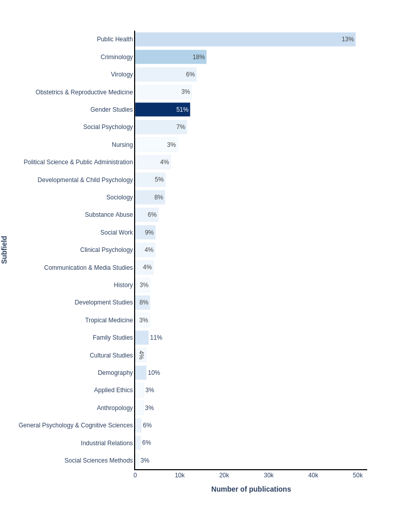

## Journals

In this section, we show how the publication set, captured by the query above, relates to scholarly journals. Journals are sorted in terms of their relevance using term frequency-inverse document frequency (TF-IDF). The horizontal bars are proportional to the number of publications contributed by the journal to the current publication set. The number alongside the horizontal bar is the proportion of the journal contributing to this publication set.

The articles on this topic are published most frequently in the following journals: *PLoS ONE* (4,091 publications), *Journal of Interpersonal Violence* (3,365), and *AIDS and Behavior* (2,762).

Note, larger journals may not appear in the table below, as their SDG contribution may be relatively small compared to the size of the journal.

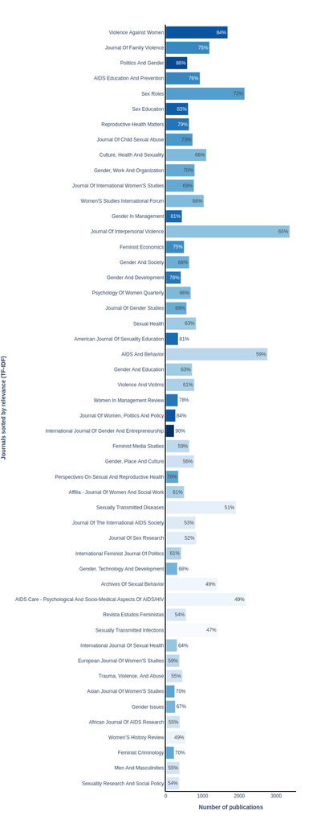

Figure 2. Top 50 journals, in terms of relevance (TF-IDF), for this publication set.

## Keywords

Elsevier’s [Scopus](https://www.scopus.com/search/form.uri?display=basic#basic) database of scientific literature, was used for the table below. The document types included in the data sets are journal articles, reviews, short surveys and conference papers, covering the period 1996–2022. We refer to these documents collectively as “publications” or “papers”.

In order to help better illustrate the content of this set of publications, indicators associated with the keywords most specific to this set (according to a TF-IDF score) are presented below.

|  | Term | # of papers with this term in the publication set | # of papers with this term in all of Scopus | Relevance (TF-IDF) | Percentage of Scopus |
| --- | --- | --- | --- | --- | --- |
| 1 | sexual risk behaviors | 2244 | 2370 | 18.8107 | 95 |
| 2 | prevention of mother-to-child transmission | 1893 | 2007 | 18.8001 | 94 |
| 3 | hiv prevention intervention | 1715 | 1817 | 18.7945 | 94 |
| 4 | consistent condom use | 2213 | 2378 | 18.7782 | 93 |
| 5 | pmtct | 1936 | 2081 | 18.7756 | 93 |
| 6 | mother-to-child transmission of hiv | 1519 | 1647 | 18.7389 | 92 |
| 7 | sexual risk behavior | 3764 | 4008 | 18.7377 | 94 |
| 8 | dating violence | 1983 | 2201 | 18.7166 | 90 |
| 9 | mtct | 2955 | 3249 | 18.715 | 91 |
| 10 | hiv prevention interventions | 1086 | 1155 | 18.7079 | 94 |

[output cut: 990 more lines]